# Statystyki opisowe - kontynuacja

## Mediana:

- mediana to sposób wyznaczenia “środka danych”
- można ją utożsamiać z wartością środkową zbioru
- jest to wartość, która dzieli uporządkowany zbiór na dwie równe połowy

## Mediana - przykład

```r
przyklad <- c(1, 11.5, 6, 7.2, 4, 8, 9, 10, 6.8, 8.3,
              2, 2, 10, 1)
```

## Mediana - przykład

```r
przyklad <- c(1, 11.5, 6, 7.2, 4, 8, 9, 10, 6.8, 8.3,
              2, 2, 10, 1)
sort(przyklad)
```

[1] 1.0 1.0 2.0 2.0 4.0 6.0 6.8 7.2 8.0 8.3 9.0 10.0 10.0 11.5

### a jaka funkcja w R oblicza medianę?

## Mediana - przykład

```r
przyklad <- c(1, 11.5, 6, 7.2, 4, 8, 9, 10, 6.8, 8.3,
              2, 2, 10, 1)
sort(przyklad)
```

[1] 1.0 1.0 2.0 2.0 4.0 6.0 6.8 7.2 8.0 8.3 9.0 10.0 10.0 11.5

### a jaka funkcja w R oblicza medianę?

```r
median(przyklad)
```

[1] 7

## Percentyle:

- dzielą dane na sto grup;
- n-ty percentyl to taka wartość, poniżej której znajduje się n procent danych;
- w dużych zbiorach danych, mediana jest pięćdziesiątym percentylem;
- mediana dolnej połowy danych, czyli dwudziesty piąty percentyl zwana jest również pierwszym kwartylem (Q1);
- mediana górnej połowy danych, czyli siedemdziesiąty piąty percentyl zwana jest również trzecim kwartylem (Q3).

## Przykład

```r
summary(przyklad)  ## wyświetla garść podstawowych statystyk opisowych
```

```
##    Min. 1st Qu.  Median    Mean 3rd Qu.    Max.
##   1.000   2.500   7.000   6.200   8.825  11.500
```

```r
var(przyklad)
```

```
## [1] 12.92769
```

```r
sd(przyklad)
```

```
## [1] 3.59551
```

## Wykresy rozkładu empirycznego cechy (zmiennej)

- Histogram
- Wykres pudełkowy

## Histogram

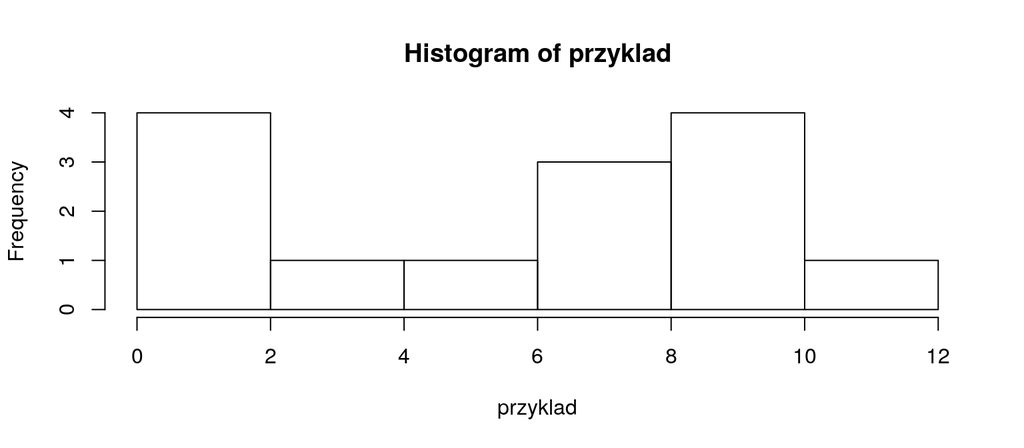

```r
przyklad <- c(1, 11.5, 6, 7.2, 4, 8, 9, 10, 6.8, 8.3,
              2, 2, 10, 1)
hist(przyklad)
```

## Histogram - podstawowe opcje wykresu

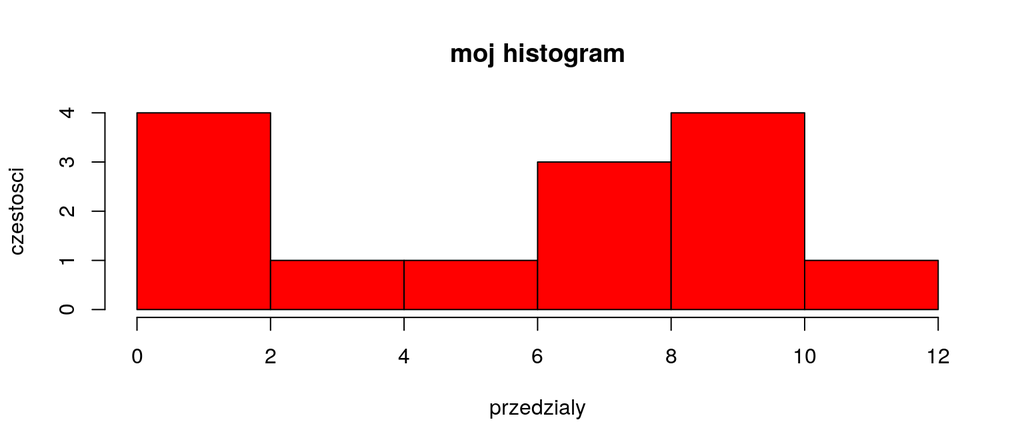

```r
przyklad <- c(1, 11.5, 6, 7.2, 4, 8, 9, 10, 6.8, 8.3,
              2, 2, 10, 1)
hist(przyklad, col="red", xlab="przedzialy", ylab="czestosci",
     main="moj histogram")
```

## Histogram - podstawowe opcje wykresu

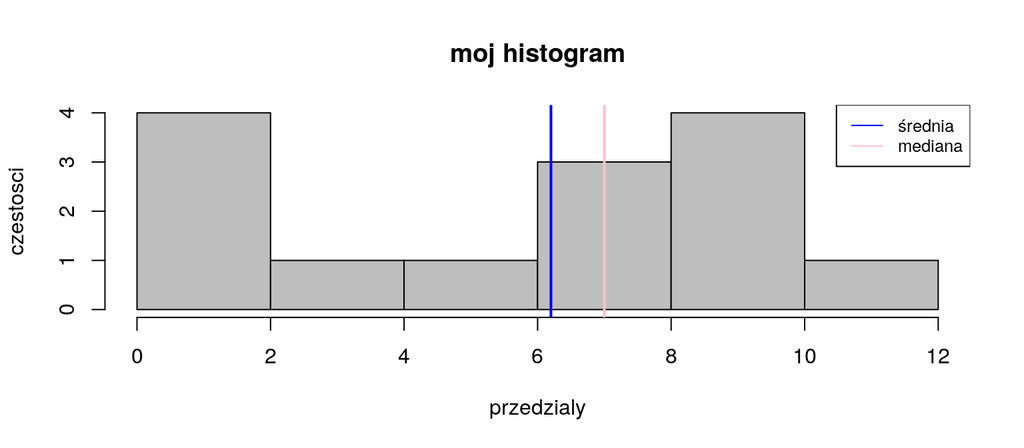

```r
hist(przyklad, col="grey", xlab="przedzialy", ylab="czestosci",
     main="moj histogram")
abline(v = mean(przyklad), col = "blue", lwd=2) ## średnia
abline(v = median(przyklad), col = "pink", lwd=2) ## mediana
# legenda
legend("topright", legend=c("średnia", "mediana"), lty=1, col=c("blue", "pink"), cex=0.8)
```

## Wykres pudełkowy

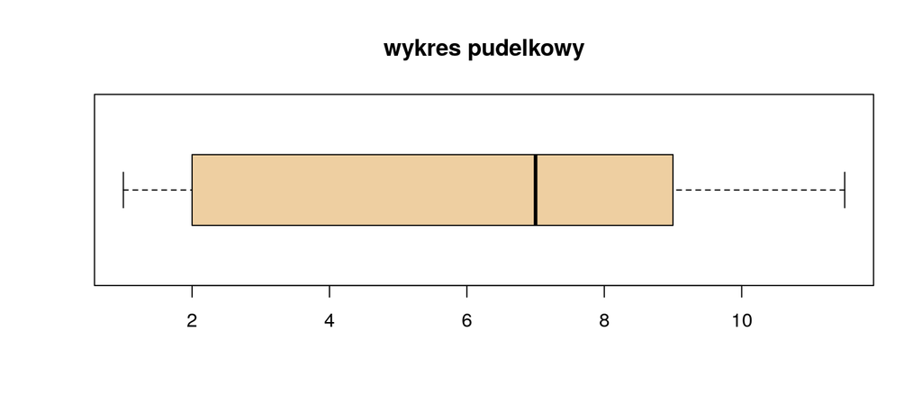

```r
boxplot(przyklad, col="navajowhite2", main="wykres pudelkowy",
        horizontal=TRUE)
```

## Skośność danych

Skośność danych miarą asymetrii obserwowanych wyników. Informuje nas o tym jak wyniki dla danej zmiennej kształtują się wokół średniej. Tzn. czy większość zaobserwowanych wyników jest z lewej strony średniej, blisko wartości średniej czy z prawej strony średniej.

- **Asymetria lewostronna → mediana > srednia**
- **Asymetria prawostronna → mediana < srednia**

## Ćwiczenie

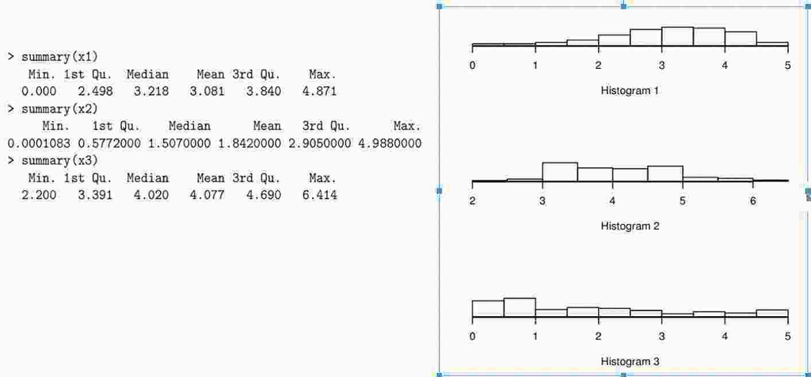

## Ćwiczenie

Będziemy pracować na obiekcie, który składa się ze 153 odczytów temperatury w NY.

```r
temp <- airquality$Temp # baza danych airquality; kolumna '$' Temp
```

1. Zamień stopnie F na C, oblicz najważniejsze statystyki opisowe dla obiektu (miary rozrzutu i środka) i zinterpretuj je.
2. Narysuj wykres pudełkowy i histogram dla obiektu. Co możesz powiedzieć o temperaturze w NY?

## Ćwiczenie

1. Oblicz najważniejsze statystyki opisowe dla obiektu (miary rozrzutu i środka) i zinterpretuj je.

```r
# Zamieńmy na Celcjusza
tempC <- ((temp-32)*5)/9

# najważniejsze miary opisowe
summary(tempC)
```

```
##    Min. 1st Qu.  Median    Mean 3rd Qu.    Max.
##   13.33   22.22   26.11   25.49   29.44   36.11
```

```r
sd(tempC)
```

```
## [1] 5.258483
```

## Ćwiczenie

1. Oblicz najważniejsze statystyki opisowe dla obiektu (miary rozrzutu i środka) i zinterpretuj je.

```r
var(tempC)
```

```
## [1] 27.65165
```

```r
max(tempC) - min(tempC)
```

```
## [1] 22.77778
```

## Ćwiczenie

1. Narysuj wykres pudełkowy i histogram dla obiektu. Co możesz powiedzieć o temperaturze w NY?

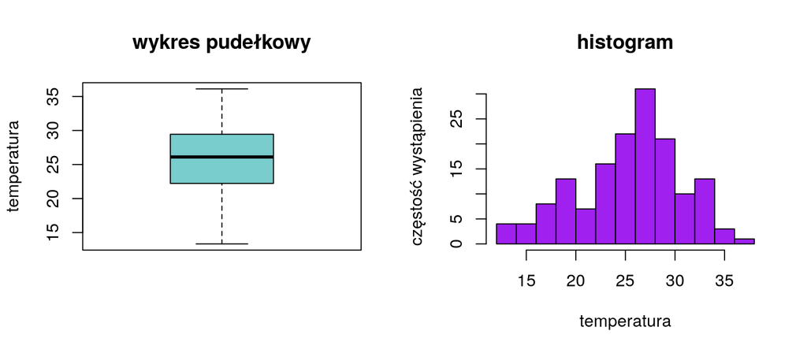

```r
par(mfrow=c(1,2))
boxplot(tempC, col="darkslategray3", ylab="temperatura", main="wykres pudełkowy")
hist(tempC, xlab="temperatura", ylab="częstość wystąpienia",
     col="purple", main="histogram")
```